# Analysis of No-Show Medical Appointments

- Functions
- Introduction
- Data Wrangling
- Exploratory Data Analysis
- Conclusions

## Functions

Implementation of the two functions that are used throughout the notebook. This section comes before the introduction because one of the two functions is used to output questions in the introduction.

```python
def print_question(question_number = 0):
    """
    Takes a question's number as an argument, prints the corresponding question in bold.
    Default argument is 0, if used, all questions are printed.
    """

    # List with all 7 questions
    questions_list = ['1- What impact does gender have on no-show?',
                      '2- Does early scheduling of appointments have an effect on no-show?',
                      '3- Are certain age groups more likely to no-show?',
                      '4- On which week days are no-shows more likely to occur?',
                      '5- Which neighbourhoods are more likely to have no-shows?',
                      '6- Are patients suffering from medical conditions less likely to no-show?',
                      '7- Does SMS have a positive effect on no-show?']

    # If no argument is provided to function, default parameter of 0 is used to print all questions
    if question_number == 0:
        for question in questions_list:
            # Print in bold
            print('\033[1m' + question + '\033[0m')
    # If an argument is provided, adjust it by deducting 1 to match the position of the question in the list
    # then print it in bold
    else:
        print('\033[1m' + questions_list[question_number - 1] + '\033[0m')
```

```python
def plot_blueprint(df, df_title, x_label, y_label, plot_type, plot_size = (6.4, 4.8)):
    """
    Generic function that takes 5 required arguments, and one optional argument: plot_size.
    Maps the arguments to the corresponding plotting function.
    """

    df.plot(kind = plot_type, figsize = plot_size)
    plt.title(df_title)
    plt.xlabel(x_label)
    plt.ylabel(y_label)
```

## Introduction

Analysis will be performed on a dataset that has information from 100k medical appointments in Brazil, it has one dependant variable, and that is whether a patient shows up to an appointment or not. All other variables are independant ones, our initial assumption is that at least few of them have an effect on the dependant variable.

Our analysis is going to uncover the correlations between the dependant variable and some of the independant ones.

### Questions to be answered:

```python
# Print all questions
print_question()
```

```
1- What impact does gender have on no-show?
2- Does early scheduling of appointments have an effect on no-show?
3- Are certain age groups more likely to no-show?
4- On which week days are no-shows more likely to occur?
5- Which neighbourhoods are more likely to have no-shows?
6- Are patients suffering from medical conditions less likely to no-show?
7- Does SMS have a positive effect on no-show?
```

## Data Wrangling

```python
# Import statements for all needed packages
import numpy as np
import pandas as pd
import matplotlib.pyplot as plt

# Magic function to render all matplotlib figures inside the notebook
%matplotlib inline
```

#### Load the dataset into a dataframe, and view top rows:

```python
df = pd.read_csv('noshowappointments-kagglev2-may-2016.csv')
```

```python
df.head()
```

|  | PatientId | AppointmentID | Gender | ScheduledDay | AppointmentDay | Age | Neighbourhood | Scholarship | Hipertension | Diabetes | Alcoholism | Handcap | SMS_received | No-show |
| --- | --- | --- | --- | --- | --- | --- | --- | --- | --- | --- | --- | --- | --- | --- |
| 0 | 2.987250e+13 | 5642903 | F | 2016-04-29T18:38:08Z | 2016-04-29T00:00:00Z | 62 | JARDIM DA PENHA | 0 | 1 | 0 | 0 | 0 | 0 | No |
| 1 | 5.589978e+14 | 5642503 | M | 2016-04-29T16:08:27Z | 2016-04-29T00:00:00Z | 56 | JARDIM DA PENHA | 0 | 0 | 0 | 0 | 0 | 0 | No |
| 2 | 4.262962e+12 | 5642549 | F | 2016-04-29T16:19:04Z | 2016-04-29T00:00:00Z | 62 | MATA DA PRAIA | 0 | 0 | 0 | 0 | 0 | 0 | No |
| 3 | 8.679512e+11 | 5642828 | F | 2016-04-29T17:29:31Z | 2016-04-29T00:00:00Z | 8 | PONTAL DE CAMBURI | 0 | 0 | 0 | 0 | 0 | 0 | No |
| 4 | 8.841186e+12 | 5642494 | F | 2016-04-29T16:07:23Z | 2016-04-29T00:00:00Z | 56 | JARDIM DA PENHA | 0 | 1 | 1 | 0 | 0 | 0 | No |

#### Drop columns that are not relevant to the analysis (Patient ID & Appointment ID):

```python
df.drop(columns = ['PatientId', 'AppointmentID'], axis = 1, inplace = True)
df.head()
```

|  | Gender | ScheduledDay | AppointmentDay | Age | Neighbourhood | Scholarship | Hipertension | Diabetes | Alcoholism | Handcap | SMS_received | No-show |
| --- | --- | --- | --- | --- | --- | --- | --- | --- | --- | --- | --- | --- |
| 0 | F | 2016-04-29T18:38:08Z | 2016-04-29T00:00:00Z | 62 | JARDIM DA PENHA | 0 | 1 | 0 | 0 | 0 | 0 | No |
| 1 | M | 2016-04-29T16:08:27Z | 2016-04-29T00:00:00Z | 56 | JARDIM DA PENHA | 0 | 0 | 0 | 0 | 0 | 0 | No |
| 2 | F | 2016-04-29T16:19:04Z | 2016-04-29T00:00:00Z | 62 | MATA DA PRAIA | 0 | 0 | 0 | 0 | 0 | 0 | No |
| 3 | F | 2016-04-29T17:29:31Z | 2016-04-29T00:00:00Z | 8 | PONTAL DE CAMBURI | 0 | 0 | 0 | 0 | 0 | 0 | No |
| 4 | F | 2016-04-29T16:07:23Z | 2016-04-29T00:00:00Z | 56 | JARDIM DA PENHA | 0 | 1 | 1 | 0 | 0 | 0 | No |

#### Rename columns for consistency (underscores instead of spaces, lower letters for everything, and some typo corrections):

```python
df.rename(columns = {'Gender': 'gender', 'ScheduledDay': 'scheduled_day', 'AppointmentDay': 'appointment_day',
                     'Age': 'age', 'Neighbourhood': 'neighbourhood', 'Scholarship': 'scholarship',
                     'Hipertension': 'hypertension', 'Diabetes': 'diabetes', 'Alcoholism': 'alcoholism',
                     'Handcap': 'handicap', 'SMS_received': 'sms_received', 'No-show': 'no_show'}, inplace = True)
df.head()
```

|  | gender | scheduled_day | appointment_day | age | neighbourhood | scholarship | hypertension | diabetes | alcoholism | handicap | sms_received | no_show |
| --- | --- | --- | --- | --- | --- | --- | --- | --- | --- | --- | --- | --- |
| 0 | F | 2016-04-29T18:38:08Z | 2016-04-29T00:00:00Z | 62 | JARDIM DA PENHA | 0 | 1 | 0 | 0 | 0 | 0 | No |
| 1 | M | 2016-04-29T16:08:27Z | 2016-04-29T00:00:00Z | 56 | JARDIM DA PENHA | 0 | 0 | 0 | 0 | 0 | 0 | No |
| 2 | F | 2016-04-29T16:19:04Z | 2016-04-29T00:00:00Z | 62 | MATA DA PRAIA | 0 | 0 | 0 | 0 | 0 | 0 | No |
| 3 | F | 2016-04-29T17:29:31Z | 2016-04-29T00:00:00Z | 8 | PONTAL DE CAMBURI | 0 | 0 | 0 | 0 | 0 | 0 | No |
| 4 | F | 2016-04-29T16:07:23Z | 2016-04-29T00:00:00Z | 56 | JARDIM DA PENHA | 0 | 1 | 1 | 0 | 0 | 0 | No |

#### Some data wrangling to decide which columns and entries are going to need cleaning:

```python
df.shape
```

```
(110527, 12)
```

#### Check for missing entries:

```python
df.isna().sum()
```

```
gender             0
scheduled_day      0
appointment_day    0
age                0
neighbourhood      0
scholarship        0
hypertension       0
diabetes           0
alcoholism         0
handicap           0
sms_received       0
no_show            0
dtype: int64
```

#### Make sure all ages are logical (no negative ages):

```python
df['age'].unique()
```

```
array([ 62,  56,   8,  76,  23,  39,  21,  19,  30,  29,  22,  28,  54,
        15,  50,  40,  46,   4,  13,  65,  45,  51,  32,  12,  61,  38,
        79,  18,  63,  64,  85,  59,  55,  71,  49,  78,  31,  58,  27,
         6,   2,  11,   7,   0,   3,   1,  69,  68,  60,  67,  36,  10,
        35,  20,  26,  34,  33,  16,  42,   5,  47,  17,  41,  44,  37,
        24,  66,  77,  81,  70,  53,  75,  73,  52,  74,  43,  89,  57,
        14,   9,  48,  83,  72,  25,  80,  87,  88,  84,  82,  90,  94,
        86,  91,  98,  92,  96,  93,  95,  97, 102, 115, 100,  99,  -1],
      dtype=int64)
```

```python
df['neighbourhood'].unique()
```

```
array(['JARDIM DA PENHA', 'MATA DA PRAIA', 'PONTAL DE CAMBURI',
       'REPÚBLICA', 'GOIABEIRAS', 'ANDORINHAS', 'CONQUISTA',
       'NOVA PALESTINA', 'DA PENHA', 'TABUAZEIRO', 'BENTO FERREIRA',
       'SÃO PEDRO', 'SANTA MARTHA', 'SÃO CRISTÓVÃO', 'MARUÍPE',
       'GRANDE VITÓRIA', 'SÃO BENEDITO', 'ILHA DAS CAIEIRAS',
       'SANTO ANDRÉ', 'SOLON BORGES', 'BONFIM', 'JARDIM CAMBURI',
       'MARIA ORTIZ', 'JABOUR', 'ANTÔNIO HONÓRIO', 'RESISTÊNCIA',
       'ILHA DE SANTA MARIA', 'JUCUTUQUARA', 'MONTE BELO',
       'MÁRIO CYPRESTE', 'SANTO ANTÔNIO', 'BELA VISTA', 'PRAIA DO SUÁ',
       'SANTA HELENA', 'ITARARÉ', 'INHANGUETÁ', 'UNIVERSITÁRIO',
       'SÃO JOSÉ', 'REDENÇÃO', 'SANTA CLARA', 'CENTRO', 'PARQUE MOSCOSO',
       'DO MOSCOSO', 'SANTOS DUMONT', 'CARATOÍRA', 'ARIOVALDO FAVALESSA',
       'ILHA DO FRADE', 'GURIGICA', 'JOANA D´ARC', 'CONSOLAÇÃO',
       'PRAIA DO CANTO', 'BOA VISTA', 'MORADA DE CAMBURI', 'SANTA LUÍZA',
       'SANTA LÚCIA', 'BARRO VERMELHO', 'ESTRELINHA', 'FORTE SÃO JOÃO',
       'FONTE GRANDE', 'ENSEADA DO SUÁ', 'SANTOS REIS', 'PIEDADE',
       'JESUS DE NAZARETH', 'SANTA TEREZA', 'CRUZAMENTO',
       'ILHA DO PRÍNCIPE', 'ROMÃO', 'COMDUSA', 'SANTA CECÍLIA',
       'VILA RUBIM', 'DE LOURDES', 'DO QUADRO', 'DO CABRAL', 'HORTO',
       'SEGURANÇA DO LAR', 'ILHA DO BOI', 'FRADINHOS', 'NAZARETH',
       'AEROPORTO', 'ILHAS OCEÂNICAS DE TRINDADE', 'PARQUE INDUSTRIAL'],
      dtype=object)
```

#### Verify no entries other than 1 or 0 are in any of the binary columns:

```python
df['scholarship'].unique()
```

```
array([0, 1], dtype=int64)
```

```python
df['hypertension'].unique()
```

```
array([1, 0], dtype=int64)
```

```python
df['diabetes'].unique()
```

```
array([0, 1], dtype=int64)
```

```python
df['alcoholism'].unique()
```

```
array([0, 1], dtype=int64)
```

```python
df['handicap'].unique()
```

```
array([0, 1, 2, 3, 4], dtype=int64)
```

#### Check how many entries other than 1 or 0 are in the handicap column:

```python
df[df['handicap'].isin([2, 3, 4])].shape[0]
```

```
199
```

```python
df['sms_received'].unique()
```

```
array([0, 1], dtype=int64)
```

```python
df['no_show'].unique()
```

```
array(['No', 'Yes'], dtype=object)
```

#### Check datatypes for all columns:

```python
df.info()
```

```
<class 'pandas.core.frame.DataFrame'>
RangeIndex: 110527 entries, 0 to 110526
Data columns (total 12 columns):
 #   Column           Non-Null Count   Dtype
---  ------           --------------   -----
 0   gender           110527 non-null  object
 1   scheduled_day    110527 non-null  object
 2   appointment_day  110527 non-null  object
 3   age              110527 non-null  int64
 4   neighbourhood    110527 non-null  object
 5   scholarship      110527 non-null  int64
 6   hypertension     110527 non-null  int64
 7   diabetes         110527 non-null  int64
 8   alcoholism       110527 non-null  int64
 9   handicap         110527 non-null  int64
 10  sms_received     110527 non-null  int64
 11  no_show          110527 non-null  object
dtypes: int64(7), object(5)
memory usage: 10.1+ MB
```

```python
df['scheduled_day'].nunique()
```

```
103549
```

```python
df['appointment_day'].nunique()
```

```
27
```

```python
df['appointment_day'].unique()
```

```
array(['2016-04-29T00:00:00Z', '2016-05-03T00:00:00Z',
       '2016-05-10T00:00:00Z', '2016-05-17T00:00:00Z',
       '2016-05-24T00:00:00Z', '2016-05-31T00:00:00Z',
       '2016-05-02T00:00:00Z', '2016-05-30T00:00:00Z',
       '2016-05-16T00:00:00Z', '2016-05-04T00:00:00Z',
       '2016-05-19T00:00:00Z', '2016-05-12T00:00:00Z',
       '2016-05-06T00:00:00Z', '2016-05-20T00:00:00Z',
       '2016-05-05T00:00:00Z', '2016-05-13T00:00:00Z',
       '2016-05-09T00:00:00Z', '2016-05-25T00:00:00Z',
       '2016-05-11T00:00:00Z', '2016-05-18T00:00:00Z',
       '2016-05-14T00:00:00Z', '2016-06-02T00:00:00Z',
       '2016-06-03T00:00:00Z', '2016-06-06T00:00:00Z',
       '2016-06-07T00:00:00Z', '2016-06-01T00:00:00Z',
       '2016-06-08T00:00:00Z'], dtype=object)
```

#### Check for duplicates:

```python
df.duplicated().sum()
```

```
635
```

### Findings from the above wrangling:

1- Columns (gender, neighbourhood, scholarship, hypertension, diabetes, alcoholism, sms_received, no_show) do not need cleaning.  
2- Columns (scheduled_day, appointment_day) need to be converted to timestamps.  
3- A column for week day name would need to be added.  
4- Column (age) has some negative entries, these must be disregarded.  
5- Column (handicap) has some entries different than 1 or 0 (2, 3, 4), these entries are all going to be converted to 1.  
6- 635 entries are duplicates, given how many different variables we have, we can assume these duplicates are indeed duplicates, not identical entries, and hence should be removed.

### Cleaning the data:

#### Drop negative age entries:

```python
df.shape
```

```
(110527, 12)
```

```python
df[df['age'] < 0].index
```

```
Int64Index([99832], dtype='int64')
```

```python
df.drop(df[df['age'] < 0].index, inplace = True)
```

```python
df[df['age'] < 0]
```

|  | gender | scheduled_day | appointment_day | age | neighbourhood | scholarship | hypertension | diabetes | alcoholism | handicap | sms_received | no_show |
| --- | --- | --- | --- | --- | --- | --- | --- | --- | --- | --- | --- | --- |

```python
df.shape
```

```
(110526, 12)
```

#### Change all (2, 3, 4) handicap entries to 1:

```python
df[df['handicap'].isin([2, 3, 4])].shape[0]
```

```
199
```

```python
# Extract index of all rows that have handicap = 2 or 3 or 4
temp_index = list(df[df['handicap'].isin([2, 3, 4])].index)
```

```python
# Loop over every index in the list of indexes, update the relevant entry of handicap to be 1 instead
for index in temp_index:
    df.loc[index, 'handicap'] = 1
```

#### Verify all entries where handicap = 2 or 3 or 4 are now gone:

```python
df[df['handicap'].isin([2, 3, 4])].shape[0]
```

```
0
```

```python
df.shape
```

```
(110526, 12)
```

```python
df['handicap'].unique()
```

```
array([0, 1], dtype=int64)
```

#### Remove duplicates:

```python
df.drop_duplicates(inplace = True)
```

```python
df.shape
```

```
(109891, 12)
```

```python
df.duplicated().sum()
```

```
0
```

#### Dates

```python
df['scheduled_day'] = pd.to_datetime(df['scheduled_day'])
df['appointment_day'] = pd.to_datetime(df['appointment_day'])
```

```python
print(df['scheduled_day'].dtype)
print(df['appointment_day'].dtype)
df.head()
```

```
datetime64[ns, UTC]
datetime64[ns, UTC]
```

|  | gender | scheduled_day | appointment_day | age | neighbourhood | scholarship | hypertension | diabetes | alcoholism | handicap | sms_received | no_show |
| --- | --- | --- | --- | --- | --- | --- | --- | --- | --- | --- | --- | --- |
| 0 | F | 2016-04-29 18:38:08+00:00 | 2016-04-29 00:00:00+00:00 | 62 | JARDIM DA PENHA | 0 | 1 | 0 | 0 | 0 | 0 | No |
| 1 | M | 2016-04-29 16:08:27+00:00 | 2016-04-29 00:00:00+00:00 | 56 | JARDIM DA PENHA | 0 | 0 | 0 | 0 | 0 | 0 | No |
| 2 | F | 2016-04-29 16:19:04+00:00 | 2016-04-29 00:00:00+00:00 | 62 | MATA DA PRAIA | 0 | 0 | 0 | 0 | 0 | 0 | No |
| 3 | F | 2016-04-29 17:29:31+00:00 | 2016-04-29 00:00:00+00:00 | 8 | PONTAL DE CAMBURI | 0 | 0 | 0 | 0 | 0 | 0 | No |
| 4 | F | 2016-04-29 16:07:23+00:00 | 2016-04-29 00:00:00+00:00 | 56 | JARDIM DA PENHA | 0 | 1 | 1 | 0 | 0 | 0 | No |

#### Since appointment day data does not have hours, I'm also going to be disregarding hours from scheduled_day columns. The analysis will only be done on day level, not day and hour level. This is a limitation reader should be aware of.

```python
df['scheduled_day'] = df['scheduled_day'].dt.date
df['appointment_day'] = df['appointment_day'].dt.date
```

```python
df.head()
```

|  | gender | scheduled_day | appointment_day | age | neighbourhood | scholarship | hypertension | diabetes | alcoholism | handicap | sms_received | no_show |
| --- | --- | --- | --- | --- | --- | --- | --- | --- | --- | --- | --- | --- |
| 0 | F | 2016-04-29 | 2016-04-29 | 62 | JARDIM DA PENHA | 0 | 1 | 0 | 0 | 0 | 0 | No |
| 1 | M | 2016-04-29 | 2016-04-29 | 56 | JARDIM DA PENHA | 0 | 0 | 0 | 0 | 0 | 0 | No |
| 2 | F | 2016-04-29 | 2016-04-29 | 62 | MATA DA PRAIA | 0 | 0 | 0 | 0 | 0 | 0 | No |
| 3 | F | 2016-04-29 | 2016-04-29 | 8 | PONTAL DE CAMBURI | 0 | 0 | 0 | 0 | 0 | 0 | No |
| 4 | F | 2016-04-29 | 2016-04-29 | 56 | JARDIM DA PENHA | 0 | 1 | 1 | 0 | 0 | 0 | No |

```python
df.nunique()
```

```
gender               2
scheduled_day      111
appointment_day     27
age                103
neighbourhood       81
scholarship          2
hypertension         2
diabetes             2
alcoholism           2
handicap             2
sms_received         2
no_show              2
dtype: int64
```

#### Adding one extra column called 'appointment_lead_days', this is equal to appointment_day minus scheduled_day, and it represents how many days in advance a patient has booked an appointment.

```python
df['appointment_lead_days'] = df['appointment_day'] - df['scheduled_day']
```

```python
df.head()
```

|  | gender | scheduled_day | appointment_day | age | neighbourhood | scholarship | hypertension | diabetes | alcoholism | handicap | sms_received | no_show | appointment_lead_days |
| --- | --- | --- | --- | --- | --- | --- | --- | --- | --- | --- | --- | --- | --- |
| 0 | F | 2016-04-29 | 2016-04-29 | 62 | JARDIM DA PENHA | 0 | 1 | 0 | 0 | 0 | 0 | No | 0 days |
| 1 | M | 2016-04-29 | 2016-04-29 | 56 | JARDIM DA PENHA | 0 | 0 | 0 | 0 | 0 | 0 | No | 0 days |
| 2 | F | 2016-04-29 | 2016-04-29 | 62 | MATA DA PRAIA | 0 | 0 | 0 | 0 | 0 | 0 | No | 0 days |
| 3 | F | 2016-04-29 | 2016-04-29 | 8 | PONTAL DE CAMBURI | 0 | 0 | 0 | 0 | 0 | 0 | No | 0 days |
| 4 | F | 2016-04-29 | 2016-04-29 | 56 | JARDIM DA PENHA | 0 | 1 | 1 | 0 | 0 | 0 | No | 0 days |

#### Adding one more column for week day name:

```python
df['appointment_day_name'] = pd.to_datetime(df['appointment_day']).dt.day_name()
```

```python
df.head()
```

|  | gender | scheduled_day | appointment_day | age | neighbourhood | scholarship | hypertension | diabetes | alcoholism | handicap | sms_received | no_show | appointment_lead_days | appointment_day_name |
| --- | --- | --- | --- | --- | --- | --- | --- | --- | --- | --- | --- | --- | --- | --- |
| 0 | F | 2016-04-29 | 2016-04-29 | 62 | JARDIM DA PENHA | 0 | 1 | 0 | 0 | 0 | 0 | No | 0 days | Friday |
| 1 | M | 2016-04-29 | 2016-04-29 | 56 | JARDIM DA PENHA | 0 | 0 | 0 | 0 | 0 | 0 | No | 0 days | Friday |
| 2 | F | 2016-04-29 | 2016-04-29 | 62 | MATA DA PRAIA | 0 | 0 | 0 | 0 | 0 | 0 | No | 0 days | Friday |
| 3 | F | 2016-04-29 | 2016-04-29 | 8 | PONTAL DE CAMBURI | 0 | 0 | 0 | 0 | 0 | 0 | No | 0 days | Friday |
| 4 | F | 2016-04-29 | 2016-04-29 | 56 | JARDIM DA PENHA | 0 | 1 | 1 | 0 | 0 | 0 | No | 0 days | Friday |

#### Just rearranging columns for a more intuitive layout:

```python
columns = df.columns
```

```python
columns
```

```
Index(['gender', 'scheduled_day', 'appointment_day', 'age', 'neighbourhood',
       'scholarship', 'hypertension', 'diabetes', 'alcoholism', 'handicap',
       'sms_received', 'no_show', 'appointment_lead_days',
       'appointment_day_name'],
      dtype='object')
```

```python
columns = ['gender', 'scheduled_day', 'appointment_day', 'appointment_day_name', 'appointment_lead_days', 'age', 'neighbourhood',
           'scholarship', 'hypertension', 'diabetes', 'alcoholism', 'handicap', 'sms_received', 'no_show']
```

```python
df = df[columns]
```

```python
df.head()
```

|  | gender | scheduled_day | appointment_day | appointment_day_name | appointment_lead_days | age | neighbourhood | scholarship | hypertension | diabetes | alcoholism | handicap | sms_received | no_show |
| --- | --- | --- | --- | --- | --- | --- | --- | --- | --- | --- | --- | --- | --- | --- |
| 0 | F | 2016-04-29 | 2016-04-29 | Friday | 0 days | 62 | JARDIM DA PENHA | 0 | 1 | 0 | 0 | 0 | 0 | No |
| 1 | M | 2016-04-29 | 2016-04-29 | Friday | 0 days | 56 | JARDIM DA PENHA | 0 | 0 | 0 | 0 | 0 | 0 | No |
| 2 | F | 2016-04-29 | 2016-04-29 | Friday | 0 days | 62 | MATA DA PRAIA | 0 | 0 | 0 | 0 | 0 | 0 | No |
| 3 | F | 2016-04-29 | 2016-04-29 | Friday | 0 days | 8 | PONTAL DE CAMBURI | 0 | 0 | 0 | 0 | 0 | 0 | No |
| 4 | F | 2016-04-29 | 2016-04-29 | Friday | 0 days | 56 | JARDIM DA PENHA | 0 | 1 | 1 | 0 | 0 | 0 | No |

## Now with all cleaning done, we can move to EDA.

## Exploratory Data Analysis

```python
print_question(1)
```

```
1- What impact does gender have on no-show?
```

#### Relative values are going to be used instead of absolute ones, value_counts() is going to be used to get count of all appointments by gender, then count of all no-shows by gender, then we will be comparing them to each other.

```python
# Create 2 data frames, one for no_show = yes (patients that didn't show up), and one for no_show = no (patients that showed up)
df_no_show = df[df['no_show'] == 'Yes']
df_show = df[df['no_show'] == 'No']
```

```python
df_no_show['gender'].value_counts()
```

```
F    14455
M     7643
Name: gender, dtype: int64
```

```python
df['gender'].value_counts()
```

```
F    71416
M    38475
Name: gender, dtype: int64
```

```python
gender_ratio = df_no_show['gender'].value_counts() / df['gender'].value_counts()
```

```python
gender_ratio = gender_ratio * 100
```

```python
gender_ratio
```

```
F    20.240562
M    19.864847
Name: gender, dtype: float64
```

```
No-show percentage for females: 20.24%
No-show percentage for males: 19.86%
```

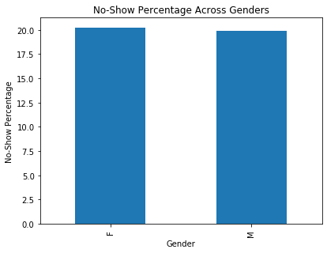

```python
# Order of arguments to the function: dataframe (or series), plot title, x-label, y-label, plot type, plot size (optional)
plot_blueprint(gender_ratio, "No-Show Percentage Across Genders", "Gender", "No-Show Percentage", "bar")

print("No-show percentage for females: {}%\nNo-show percentage for males: {}%"
      .format(round(gender_ratio[0], 2), round(gender_ratio[1], 2)))
```

```python
print_question(2)
```

```
2- Does early scheduling of appointments have an effect on no-show?
```

#### Comparison of how many days all appointments are booked in advance versus how many days no-show appointments are booked in advance.

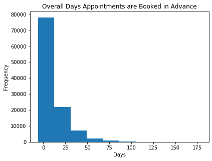

```python
# Order of arguments to the function: dataframe (or series), plot title, x-label, y-label, plot type, plot size (optional)
plot_blueprint(df['appointment_lead_days'].dt.days, "Overall Days Appointments are Booked in Advance",
               "Days", "Frequency", "hist")
```

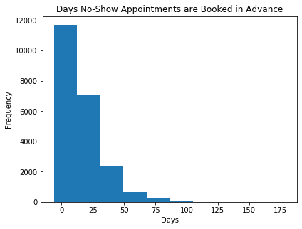

```python
# Order of arguments to the function: dataframe (or series), plot title, x-label, y-label, plot type, plot size (optional)
plot_blueprint(df_no_show['appointment_lead_days'].dt.days, "Days No-Show Appointments are Booked in Advance",
               "Days", "Frequency", "hist")
```

```python
print_question(3)
```

```
3- Are certain age groups more likely to no-show?
```

#### Similar to the last question, age groups for all appointments are going to be compared versus age groups for no-show appointments.

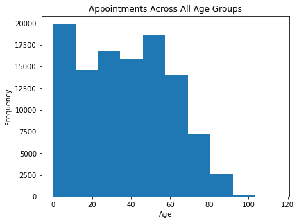

```python
# Order of arguments to the function: dataframe (or series), plot title, x-label, y-label, plot type, plot size (optional)
plot_blueprint(df['age'], "Appointments Across All Age Groups", "Age", "Frequency", "hist")
```

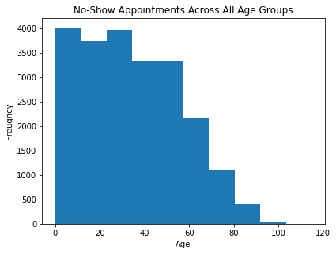

```python
# Order of arguments to the function: dataframe (or series), plot title, x-label, y-label, plot type, plot size (optional)
plot_blueprint(df_no_show['age'], "No-Show Appointments Across All Age Groups", "Age", "Freuqncy", "hist")
```

```python
print_question(4)
```

```
4- On which week days are no-shows more likely to occur?
```

#### Relative values are going to be used instead of absolute ones. Very few data points exist for Saturday, results therefore might not be very reliable. No data points exist for Sunday.

```python
df['appointment_day_name'].value_counts()
```

```
Wednesday    25739
Tuesday      25507
Monday       22573
Friday       18859
Thursday     17174
Saturday        39
Name: appointment_day_name, dtype: int64
```

```python
df_no_show['appointment_day_name'].value_counts()
```

```
Tuesday      5099
Wednesday    5053
Monday       4635
Friday       3990
Thursday     3312
Saturday        9
Name: appointment_day_name, dtype: int64
```

```python
day_name_ratio = df_no_show['appointment_day_name'].value_counts() / df['appointment_day_name'].value_counts()
```

```python
day_name_ratio = day_name_ratio * 100
```

```python
day_name_ratio = day_name_ratio.sort_values()
```

```python
day_name_ratio
```

```
Thursday     19.284966
Wednesday    19.631687
Tuesday      19.990591
Monday       20.533381
Friday       21.157007
Saturday     23.076923
Name: appointment_day_name, dtype: float64
```

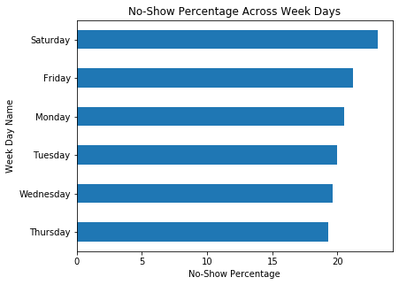

```python
# Order of arguments to the function: dataframe (or series), plot title, x-label, y-label, plot type, plot size (optional)
plot_blueprint(day_name_ratio, "No-Show Percentage Across Week Days", "No-Show Percentage", "Week Day Name", "barh")
```

```python
print_question(5)
```

```
5- Which neighbourhoods are more likely to have no-shows?
```

```python
# Select only neighbourhoods that have at least 2000 apointments
appointments_by_neighbourhood = df['neighbourhood'].value_counts()
appointments_by_neighbourhood = appointments_by_neighbourhood[appointments_by_neighbourhood >= 2000]
```

```python
# Extract indexes and convert them to a list
selected_neighbourhoods = list(appointments_by_neighbourhood.index)
```

```python
# Use the list to query on the no-show dataframe
selected_neighbourhoods_no_show = df_no_show[df_no_show['neighbourhood'].isin(selected_neighbourhoods)]
```

```python
no_show_by_neighbourhood = selected_neighbourhoods_no_show['neighbourhood'].value_counts()
```

```python
neighbourhood_ratio = no_show_by_neighbourhood/appointments_by_neighbourhood
```

```python
neighbourhood_ratio = (neighbourhood_ratio * 100).sort_values()
```

```python
neighbourhood_ratio
```

```
SANTA MARTHA         15.758943
JARDIM DA PENHA      16.292280
SANTO ANTÔNIO        17.489938
NOVA PALESTINA       17.764030
JABOUR               17.989629
TABUAZEIRO           18.187640
JARDIM CAMBURI       18.763130
DA PENHA             19.428053
SANTO ANDRÉ          19.718310
BONFIM               19.847881
RESISTÊNCIA          20.173239
SÃO PEDRO            20.937886
CENTRO               20.996979
MARIA ORTIZ          21.002757
ROMÃO                21.174863
GURIGICA             22.559761
ANDORINHAS           22.652689
CARATOÍRA            22.943723
ILHA DO PRÍNCIPE     23.477493
JESUS DE NAZARETH    24.368864
ITARARÉ              25.994236
Name: neighbourhood, dtype: float64
```

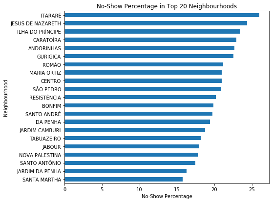

```python
# Order of arguments to the function: dataframe (or series), plot title, x-label, y-label, plot type, plot size (optional)
plot_blueprint(neighbourhood_ratio, "No-Show Percentage in Top 20 Neighbourhoods", "No-Show Percentage",
             "Neighbourhood", "barh", plot_size = (7.5, 6.5))
```

```python
print_question(6)
```

```
6- Are patients suffering from medical conditions less likely to no-show?
```

#### Medical condition is assumed to be hypertension, diabetes, handicap, or any combination of the three.

```python
# New dataframe with only patients that suffer from any of the 3 conditions
patients_with_condition = df[(df['hypertension'] == 1) | (df['diabetes'] == 1) | (df['handicap'] == 1)]
```

```python
# Count of the patients is retrieved using the shape[0] of the new dataframe, to avoid counting patients multiple times
# if they are suffering from multiple conditions
patients_with_condition_count = patients_with_condition[['hypertension', 'diabetes', 'handicap']].shape[0]
```

```python
# Same as above 2 cells repeated for no-show dataframe
patients_with_condition_no_show = df_no_show[(df_no_show['hypertension'] == 1)
                                             | (df_no_show['diabetes'] == 1)
                                             | (df_no_show['handicap'] == 1)]
patients_with_condition_count_no_show = patients_with_condition_no_show[['hypertension', 'diabetes', 'handicap']].shape[0]
```

```python
patients_with_condition_no_show_percentage = patients_with_condition_count_no_show / patients_with_condition_count
```

```python
patients_with_condition_no_show_percentage = round((patients_with_condition_no_show_percentage * 100), 2)
```

```python
# New Dataframe with patients that do not suffer from any of the 3 conditions
patients_without_condition = df[(df['hypertension'] == 0) & (df['diabetes'] == 0) & (df['handicap'] == 0)]
```

```python
patients_without_condition_count = patients_without_condition[['hypertension', 'diabetes', 'handicap']].shape[0]
```

```python
patients_without_condition_no_show = df_no_show[(df_no_show['hypertension'] == 0)
                                             & (df_no_show['diabetes'] == 0)
                                             & (df_no_show['handicap'] == 0)]
patients_without_condition_no_show = patients_without_condition_no_show[['hypertension', 'diabetes', 'handicap']].shape[0]
```

```python
patients_without_condition_no_show_percentage = patients_without_condition_no_show / patients_without_condition_count
```

```python
patients_without_condition_no_show_percentage = round((patients_without_condition_no_show_percentage * 100), 2)
```

```python
print("{}% of patients with a medical condition didn't show up\n{}% of patients without a medical condition didn't show up"
      .format(patients_with_condition_no_show_percentage, patients_without_condition_no_show_percentage))
```

```
17.46% of patients with a medical condition didn't show up
20.86% of patients without a medical condition didn't show up
```

```python
print_question(7)
```

```
7- Does SMS have a positive effect on no-show?
```

#### Compare no-show percentage for patients that received SMS and patients that didn't.

```python
# Get counts for SMS received and not received
df['sms_received'].value_counts()
```

```
0    74409
1    35482
Name: sms_received, dtype: int64
```

```python
sms_not_received = df['sms_received'].value_counts()[0]
sms_received = df['sms_received'].value_counts()[1]
```

```python
# Get no-show counts for patients that did not receive SMS
df[df['sms_received'] == 0]['no_show'].value_counts()
```

```
No     62095
Yes    12314
Name: no_show, dtype: int64
```

```python
sms_not_received_show = df[df['sms_received'] == 0]['no_show'].value_counts()[0]
sms_not_received_no_show = df[df['sms_received'] == 0]['no_show'].value_counts()[1]
```

```python
# Get no-show counts for patients that received SMS
df[df['sms_received'] == 1]['no_show'].value_counts()
```

```
No     25698
Yes     9784
Name: no_show, dtype: int64
```

```python
sms_received_show = df[df['sms_received'] == 1]['no_show'].value_counts()[0]
sms_received_no_show = df[df['sms_received'] == 1]['no_show'].value_counts()[1]
```

```python
print(sms_received)
print(sms_received_show)
print(sms_received_no_show)
```

```
35482
25698
9784
```

```python
print(sms_not_received)
print(sms_not_received_show)
print(sms_not_received_no_show)
```

```
74409
62095
12314
```

```python
received_no_show = sms_received_no_show / sms_received
```

```python
received_no_show = round((received_no_show * 100), 2)
```

```python
not_received_no_show = sms_not_received_no_show / sms_not_received
```

```python
not_received_no_show = round((not_received_no_show * 100), 2)
```

```python
print("{}% of the patients that received SMS did not show up\n{}% of the patients that did not receive SMS did not show"
      .format(received_no_show, not_received_no_show))
```

```
27.57% of the patients that received SMS did not show up
16.55% of the patients that did not receive SMS did not show
```

## Conclusions

### Looking back at our initial questions:

```python
print_question(1)
```

```
1- What impact does gender have on no-show?
```

Gender doesn't appear to have much impact on the probability of no-show. 20.24% of the females that booked appointments did not show, while 19.86% of the males did not show. This is a difference of 0.38%.

```
No-show percentage for females: 20.24%
No-show percentage for males: 19.86%
```

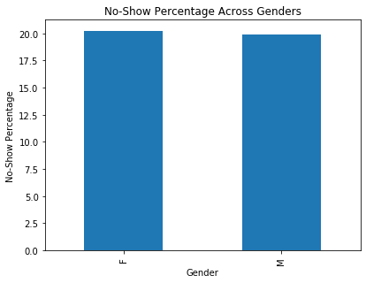

```python
plot_blueprint(gender_ratio, "No-Show Percentage Across Genders", "Gender", "No-Show Percentage", "bar")

print("No-show percentage for females: {}%\nNo-show percentage for males: {}%"
      .format(round(gender_ratio[0], 2), round(gender_ratio[1], 2)))
```

```python
print_question(2)
```

```
2- Does early scheduling of appointments have an effect on no-show?
```

Yes, early scheduling seems to have an effect on no-show.

Patients that schedule appointments between around 10 and 50 days appear to be more likely to no-show. This can be observed in the distribution of the 2 histograms below. The 1st one is for the overall distribution of how many days appointments are booked in advance, the 2nd one is for the distribution of the days for the patients that did not show up.

The skewness appears to be caused by the groups of patients that book between around 10 and 50 days in advance.

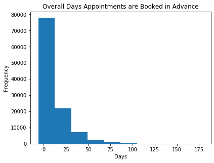

```python
plot_blueprint(df['appointment_lead_days'].dt.days, "Overall Days Appointments are Booked in Advance",
               "Days", "Frequency", "hist")
```

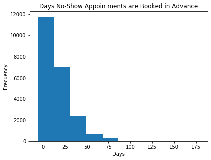

```python
plot_blueprint(df_no_show['appointment_lead_days'].dt.days, "Days No-Show Appointments are Booked in Advance",
               "Days", "Frequency", "hist")
```

```python
print_question(3)
```

```
3- Are certain age groups more likely to no-show?
```

Yes, the age groups between around 10 to 50 appear more likely to no-show, the other two age groups (less than 10 and more than 50) appear to be less likely to no-show. This observation is based on the change in the skewness between the 2 histograms below, where the 1st one is for the whole dataset, and the 2nd one is for the patients that did not show.

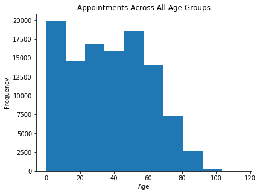

```python
plot_blueprint(df['age'], "Appointments Across All Age Groups", "Age", "Frequency", "hist")
```

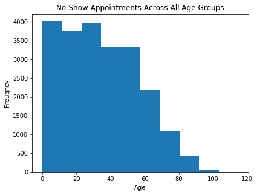

```python
plot_blueprint(df_no_show['age'], "No-Show Appointments Across All Age Groups", "Age", "Freuqncy", "hist")
```

```python
print_question(4)
```

```
4- On which week days are no-shows more likely to occur?
```

No-shows are most likely to occur on Saturday, followed by Fridays. Please refer to the figure below for details of all days.

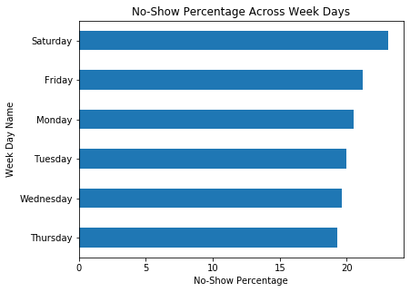

```python
plot_blueprint(day_name_ratio, "No-Show Percentage Across Week Days", "No-Show Percentage", "Week Day Name", "barh")
```

```python
print_question(5)
```

```
5- Which neighbourhoods are more likely to have no-shows?
```

Only neighbourhoods that have at least 2000 booked appointments have been considered in this analysis.

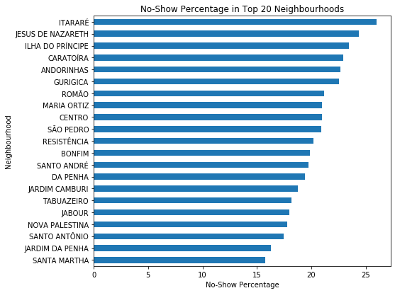

```python
plot_blueprint(neighbourhood_ratio, "No-Show Percentage in Top 20 Neighbourhoods", "No-Show Percentage",
             "Neighbourhood", "barh", plot_size = (7.5, 6.5))
```

```python
print_question(6)
```

```
6- Are patients suffering from medical conditions less likely to no-show?
```

Yes, patients suffering from medical conditions appear to be less likely to no-show. A medical condition is assumed to be hypertension, diabetes, handicap, or any combination of the three.

17.46% of patients with a medical condition didn't show up, 20.86% of patients without a medical condition didn't show up.

Patients with a medical condition appear to be 3.4% less likely to no-show.

```python
print_question(7)
```

```
7- Does SMS have a positive effect on no-show?
```

No, SMS appears to have a negative effect on no-show.

27.57% of the patients that received SMS did not show up, 16.55% of the patients that did not receive SMS did not show up.

Patients that received SMS appear to be 11.02% more likely to no-show.

### Limitations:

1- The dataset in use is a sample dataset, it doesn't represent a population, this implies a certain degree of uncertainity in the results.  
2- No statistical inference was performed, the significance of the results therefore has not been evaluated.  
3- On question 2, does early scheduling of appointments have an effect on no-show, the dataset does not include appointment hours, only appointment days. Appointment hours could be playing a role in the probability of no-show, but this cannot be deduced from the dataset.  
4- On question 4, on which week days are no-shows more likely to occur, very few data points exist for Saturday, the result associated with it therefore might be less reliable than any other day.  
5- Not exactly a limitation, but worthy of highlighting nevertheless, on question 7, does SMS have a positive effect on no-show, patients that receive SMS appear to be 11.02% more likely to no-show. Given how counter-intuitive this result is, reader should be skeptical to consider this correlation.